# hab1

Lukáš Hejtmánek

Wed Jul 08 18:54:58 2020

## Summative heatmaps

### females

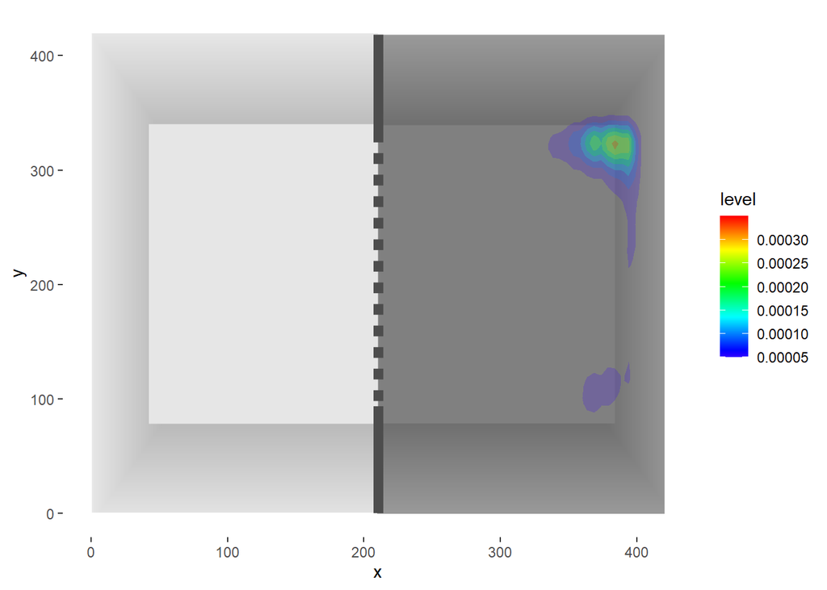

### males

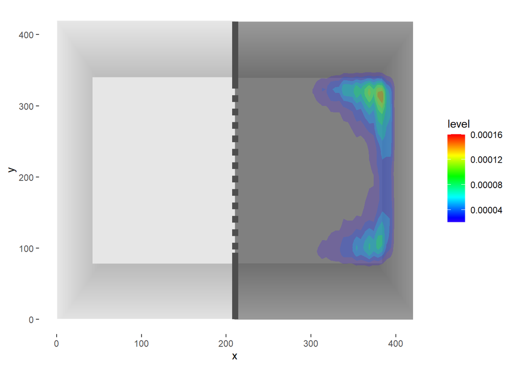

### Individual animals

animal_1

Animal:

animal_1

Distance:

29561.27

Time in left zone:

NA

Time in right zone:

899.52

Time in central zone:

NA

Crosses to the right:

0

Crosses to the left:

0

Number of freezes:

5

Total freeze time:

16.47

Freeze time ratio:

0.02

Animal:

animal_1

Distance:

31718.22

Time in left zone:

NA

Time in right zone:

899.1

Time in central zone:

NA

Crosses to the right:

0

Crosses to the left:

0

Number of freezes:

3

Total freeze time:

16.01

Freeze time ratio:

0.02

animal_10

Animal:

animal_10

Distance:

25288.92

Time in left zone:

NA

Time in right zone:

899.6

Time in central zone:

NA

Crosses to the right:

0

Crosses to the left:

0

Number of freezes:

16

Total freeze time:

77.64

Freeze time ratio:

0.09

Animal:

animal_10

Distance:

21108.23

Time in left zone:

NA

Time in right zone:

899.84

Time in central zone:

NA

Crosses to the right:

0

Crosses to the left:

0

Number of freezes:

19

Total freeze time:

156.44

Freeze time ratio:

0.17

animal_2

Animal:

animal_2

Distance:

47838.81

Time in left zone:

48.37

Time in right zone:

843.51

Time in central zone:

6.63

Crosses to the right:

5

Crosses to the left:

5

Number of freezes:

2

Total freeze time:

12.21

Freeze time ratio:

0.01

Animal:

animal_2

Distance:

22306.65

Time in left zone:

NA

Time in right zone:

894.18

Time in central zone:

NA

Crosses to the right:

0

Crosses to the left:

0

Number of freezes:

20

Total freeze time:

137.08

Freeze time ratio:

0.15

animal_3

Animal:

animal_3

Distance:

32003.94

Time in left zone:

NA

Time in right zone:

899.01

Time in central zone:

NA

Crosses to the right:

0

Crosses to the left:

0

Number of freezes:

5

Total freeze time:

30.24

Freeze time ratio:

0.03

Animal:

animal_3

Distance:

20353.53

Time in left zone:

NA

Time in right zone:

899.94

Time in central zone:

NA

Crosses to the right:

0

Crosses to the left:

0

Number of freezes:

20

Total freeze time:

206.86

Freeze time ratio:

0.23

animal_4

Animal:

animal_4

Distance:

21510.69

Time in left zone:

NA

Time in right zone:

897.38

Time in central zone:

NA

Crosses to the right:

0

Crosses to the left:

0

Number of freezes:

19

Total freeze time:

266

Freeze time ratio:

0.3

Animal:

animal_4

Distance:

31455.58

Time in left zone:

NA

Time in right zone:

896.89

Time in central zone:

3.02

Crosses to the right:

0

Crosses to the left:

0

Number of freezes:

3

Total freeze time:

7.4

Freeze time ratio:

0.01

animal_5

Animal:

animal_5

Distance:

25211.46

Time in left zone:

NA

Time in right zone:

895.64

Time in central zone:

NA

Crosses to the right:

0

Crosses to the left:

0

Number of freezes:

13

Total freeze time:

172.05

Freeze time ratio:

0.19

Animal:

animal_5

Distance:

26496.33

Time in left zone:

NA

Time in right zone:

899.41

Time in central zone:

NA

Crosses to the right:

0

Crosses to the left:

0

Number of freezes:

7

Total freeze time:

51.75

Freeze time ratio:

0.06

animal_6

Animal:

animal_6

Distance:

26338.9

Time in left zone:

NA

Time in right zone:

886.63

Time in central zone:

NA

Crosses to the right:

0

Crosses to the left:

0

Number of freezes:

15

Total freeze time:

108.53

Freeze time ratio:

0.12

Animal:

animal_6

Distance:

25520.6

Time in left zone:

NA

Time in right zone:

890.53

Time in central zone:

NA

Crosses to the right:

0

Crosses to the left:

0

Number of freezes:

12

Total freeze time:

98.33

Freeze time ratio:

0.11

animal_7

Animal:

animal_7

Distance:

28810.5

Time in left zone:

NA

Time in right zone:

898.29

Time in central zone:

NA

Crosses to the right:

0

Crosses to the left:

0

Number of freezes:

16

Total freeze time:

86.24

Freeze time ratio:

0.1

Animal:

animal_7

Distance:

29911.5

Time in left zone:

NA

Time in right zone:

898

Time in central zone:

NA

Crosses to the right:

0

Crosses to the left:

0

Number of freezes:

7

Total freeze time:

56.23

Freeze time ratio:

0.06

animal_8

Animal:

animal_8

Distance:

26149.86

Time in left zone:

NA

Time in right zone:

891.39

Time in central zone:

NA

Crosses to the right:

0

Crosses to the left:

0

Number of freezes:

19

Total freeze time:

115.49

Freeze time ratio:

0.13

Animal:

animal_8

Distance:

24911.61

Time in left zone:

NA

Time in right zone:

895.74

Time in central zone:

NA

Crosses to the right:

0

Crosses to the left:

0

Number of freezes:

14

Total freeze time:

118.04

Freeze time ratio:

0.13

animal_9

Animal:

animal_9

Distance:

24521.88

Time in left zone:

NA

Time in right zone:

899.4

Time in central zone:

NA

Crosses to the right:

0

Crosses to the left:

0

Number of freezes:

8

Total freeze time:

47.71

Freeze time ratio:

0.05

Animal:

animal_9

Distance:

27789.2

Time in left zone:

NA

Time in right zone:

892.3

Time in central zone:

NA

Crosses to the right:

0

Crosses to the left:

0

Number of freezes:

15

Total freeze time:

99.67

Freeze time ratio:

0.11

## Summary statistics

#### females

Animal:

Distance:

28723.62

Time in left zone:

48.37

Time in right zone:

891.04

Time in central zone:

6.63

Crosses to the right:

0.5

Crosses to the left:

0.5

Number of freezes:

11.8

Total freeze time:

93.26

Freeze time ratio:

0.1

#### males

Animal:

Distance:

26157.15

Time in left zone:

NaN

Time in right zone:

896.59

Time in central zone:

3.02

Crosses to the right:

0

Crosses to the left:

0

Number of freezes:

12

Total freeze time:

94.78

Freeze time ratio:

0.11